# crosslink An R package for network visualization of grouped nodes

The goal of crosslink is to visualize the network of grouped nodes

## 1. Installation

You can install the released version of crosslink from [github](https://github.com/zzwch/crosslink) with:

```r
devtools::install_github("zzwch/crosslink")
library(crosslink)
```

## 2. Quick start

Examples of typical crosslonk usage.

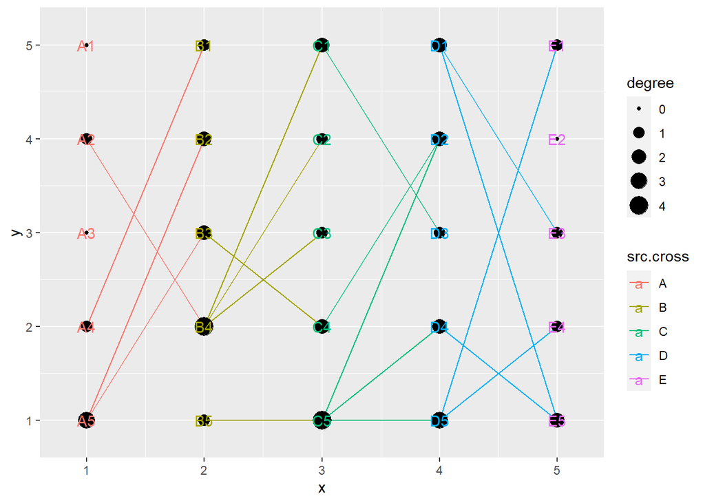

```r
cl <- crosslink(demo$nodes, demo$edges, demo$cross.by, odd.rm = F,spaces = "flank")
cl %>% cl_plot()
```

## 3. Step by step

This is a basic example of the basic function of crosslink packages,including 1). Input data 2). Generate CrossLink class 3). Coordinate transformation 4). Layout modules 5). Plotting modules

### 1). Input data

crosslink needs two files as input. a. nodes (must have two columns: node name and node type) b. edges data (must have two columns: source node and target node).

crosslink also provides the function ‘gen_demo’ to generate demo data.

```r
# generate demo data
n <- 6
demo <- gen_demo(n_cross = n,n_node = 4:(n+3), n_link = 3:(n+1), seed = 66)
nodes <- demo$nodes
edges <- demo$edges
cross.by <- demo$cross.by
```

### 2). Generate crossLink class

crosslink can help to generate an object of crosslink class for plot.

```r
# users can define 'odd.rm' to choose if remove the nodes have zero relationship with any other nodes when generate crosslink class
# user can set intervals between nodes and gaps through spaces and gaps.
cl <- crosslink(nodes, edges, cross.by, odd.rm = F,spaces = "flank")

cl %>% get_cross()   # get node information
```

```
##     node node.type x        y cross key type degree
## A2    A4      node 1 2.000000     A  A4    A      0
## A3    A3      node 1 4.000000     A  A3    A      1
## A4    A2      node 1 6.000000     A  A2    A      0
## A5    A1      node 1 8.000000     A  A1    A      2
## B2    B5      node 2 1.666667     B  B5    B      1
## B3    B4      node 2 3.333333     B  B4    B      2
## B4    B3      node 2 5.000000     B  B3    B      1
## B5    B2      node 2 6.666667     B  B2    B      2
## B6    B1      node 2 8.333333     B  B1    B      1
## C2    C6      node 3 1.428571     C  C6    C      0
## C3    C5      node 3 2.857143     C  C5    C      1
## C4    C4      node 3 4.285714     C  C4    C      4
## C5    C3      node 3 5.714286     C  C3    C      1
## C6    C2      node 3 7.142857     C  C2    C      2
## C7    C1      node 3 8.571429     C  C1    C      1
## D2    D7      node 4 1.250000     D  D7    D      0
## D3    D6      node 4 2.500000     D  D6    D      6
## D4    D5      node 4 3.750000     D  D5    D      3
## D5    D4      node 4 5.000000     D  D4    D      0
## D6    D3      node 4 6.250000     D  D3    D      1
## D7    D2      node 4 7.500000     D  D2    D      0
## D8    D1      node 4 8.750000     D  D1    D      1
## E2    E8      node 5 1.111111     E  E8    E      2
## E3    E7      node 5 2.222222     E  E7    E      1
## E4    E6      node 5 3.333333     E  E6    E      0
## E5    E5      node 5 4.444444     E  E5    E      3
## E6    E4      node 5 5.555556     E  E4    E      2
## E7    E3      node 5 6.666667     E  E3    E      1
## E8    E2      node 5 7.777778     E  E2    E      2
## E9    E1      node 5 8.888889     E  E1    E      2
## F2    F9      node 6 1.000000     F  F9    F      1
## F3    F8      node 6 2.000000     F  F8    F      0
## F4    F7      node 6 3.000000     F  F7    F      1
## F5    F6      node 6 4.000000     F  F6    F      0
## F6    F5      node 6 5.000000     F  F5    F      3
## F7    F4      node 6 6.000000     F  F4    F      2
## F8    F3      node 6 7.000000     F  F3    F      0
## F9    F2      node 6 8.000000     F  F2    F      0
## F10   F1      node 6 9.000000     F  F1    F      0
```

```r
cl %>% get_link()    # get edges information
```

```
##    src tar src.cross tar.cross source target x        y xend     yend
## 1   A1  B4         A         B     A1     B4 1 8.000000    2 3.333333
## 2   A3  B2         A         B     A3     B2 1 4.000000    2 6.666667
## 3   A1  B5         A         B     A1     B5 1 8.000000    2 1.666667
## 4   B3  C2         B         C     B3     C2 2 5.000000    3 7.142857
## 5   B2  C4         B         C     B2     C4 2 6.666667    3 4.285714
## 6   B1  C3         B         C     B1     C3 2 8.333333    3 5.714286
## 7   B4  C4         B         C     B4     C4 2 3.333333    3 4.285714
## 8   C4  D3         C         D     C4     D3 3 4.285714    4 6.250000
## 9   C5  D5         C         D     C5     D5 3 2.857143    4 3.750000
## 10  C2  D6         C         D     C2     D6 3 7.142857    4 2.500000
## 11  C4  D6         C         D     C4     D6 3 4.285714    4 2.500000
## 12  C1  D6         C         D     C1     D6 3 8.571429    4 2.500000
## 13  D6  E4         D         E     D6     E4 4 2.500000    5 5.555556
## 14  D6  E5         D         E     D6     E5 4 2.500000    5 4.444444
## 15  D1  E3         D         E     D1     E3 4 8.750000    5 6.666667
## 16  D5  E8         D         E     D5     E8 4 3.750000    5 1.111111
## 17  D6  E2         D         E     D6     E2 4 2.500000    5 7.777778
## 18  D5  E5         D         E     D5     E5 4 3.750000    5 4.444444
## 19  E2  F4         E         F     E2     F4 5 7.777778    6 6.000000
## 20  E4  F5         E         F     E4     F5 5 5.555556    6 5.000000
## 21  E5  F4         E         F     E5     F4 5 4.444444    6 6.000000
## 22  E7  F7         E         F     E7     F7 5 2.222222    6 3.000000
## 23  E8  F5         E         F     E8     F5 5 1.111111    6 5.000000
## 24  E1  F9         E         F     E1     F9 5 8.888889    6 1.000000
## 25  E1  F5         E         F     E1     F5 5 8.888889    6 5.000000
```

```r
cl %>% cl_layouts()  # get layouts information of crosslink object
```

```
## [1] "default"
```

```r
cl %>% cl_active()   # get active layouts information of crosslink object
```

```
## [1] "default"
```